# CourseraMachineLearning

M_Raess

March 18, 2017

```r
library(caret)
library(rpart)
library(rpart.plot)
library(rattle)
library(randomForest)
library(corrplot)
set.seed(666)
```

In this project, I will predict the manner, in which an exercise was executed (A, B, C, D, or E) - the “classe”-variable.

## First, we have to read in the data.

```r
train_pml0 <- read.csv("pml-training.csv", header = TRUE, na.strings = c("NA", ""))

test_pml <- read.csv("pml-testing.csv", header = TRUE, na.strings = c("NA", ""))
```

Having read in the data, we need to do some data cleaning first (it is important to remember to apply the same steps to the testing set later!!).

### 1. For prediction, we will first have to inspect the variables to find out which ones are useful.

`str(train_pml)` reveals that there are several variables that are set to factor, while they actually appear to have numeric values. We find that some variables are indeed useless (`levels(train_pml$kurtosis_yaw_belt)`), while others have a wide range of numberic values.

```r
vars <- c(
  "X", "user_name", "raw_timestamp_part_1", "raw_timestamp_part_2",
  "kurtosis_yaw_belt", "skewness_yaw_belt", "amplitude_yaw_belt", "cvtd_timestamp",
  "kurtosis_yaw_dumbbell", "skewness_yaw_dumbbell", "amplitude_yaw_dumbbell",
  "kurtosis_yaw_forearm", "skewness_yaw_forearm", "amplitude_yaw_forearm")

train_pml <- train_pml0[, -which(names(train_pml0) %in% vars)]
```

Now, we convert the factor variables to numberic

```r
vars_fact <- c(
  "kurtosis_roll_belt", "kurtosis_picth_belt", "skewness_roll_belt",
  "skewness_roll_belt.1", "max_yaw_belt", "min_yaw_belt",
  "kurtosis_roll_arm","kurtosis_picth_arm", "kurtosis_yaw_arm",
  "skewness_roll_arm","skewness_pitch_arm", "skewness_yaw_arm",
  "kurtosis_roll_dumbbell", "kurtosis_picth_dumbbell","skewness_roll_dumbbell",
  "skewness_pitch_dumbbell","max_yaw_dumbbell", "min_yaw_dumbbell",
  "kurtosis_roll_forearm","kurtosis_picth_forearm", "skewness_roll_forearm",
  "skewness_pitch_forearm", "max_yaw_forearm", "min_yaw_forearm")

for (v in vars_fact) {
  train_pml[[v]] <- as.numeric(as.character(train_pml[[v]]))
}
```

Since there are still a lot of variables (146), we will further reduce the number of variables

The near zero variance (NZV) variables are also removed and the ID variables as well.

```r
NZV <- nearZeroVar(train_pml)
train_pml <- train_pml[,-NZV]
dim(train_pml)
```

[output not shown]

```r
data_NA   <- sapply(train_pml, function(x) mean(is.na(x))) > 0.95
train_pml <- train_pml[, data_NA==FALSE]

dim(train_pml)
```

[output not shown]

Finally, we remove variables only used for identification (vars 1:5)

```r
library(dplyr)
train_pml <- select(train_pml, -c(1:5))

dim(train_pml)
```

[output not shown]

### 2. Data sets and exploratory data analysis

First, we break the *train_pml* dataset up into a train and a validation set.

```r
set.seed(666)
inTrain <- createDataPartition(train_pml$classe, p = 0.7, list = FALSE)

train <- train_pml[inTrain,]
validation <- train_pml[-inTrain,]
```

Let’s see which variables are strongly correlated.

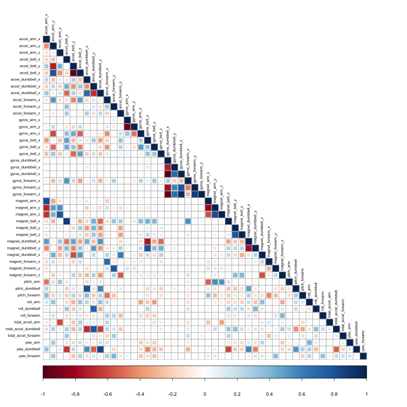

Correlation matrix

```r
cor_matrix <- cor(train[,-49])
corrplot(cor_matrix, order = "alphabet", method = "square", type = "lower", tl.cex = 0.6, tl.col = rgb(0,0,0))
```

Since there are only a few strong correlations, PCA will not be applied and I will move forward with the train and validation datasets

## 3. Model building

### Random forest

```r
set.seed(666) # for reproducability

rf_control <- trainControl(method = "cv", number = 3, verboseIter = FALSE) # crossvalidation will be used

mod_rf <- train(classe ~ ., data = train, method = "rf", trControl = rf_control)

mod_rf$finalModel
```

```
##
## Call:
##  randomForest(x = x, y = y, mtry = param$mtry)
##                Type of random forest: classification
##                      Number of trees: 500
## No. of variables tried at each split: 25
##
##         OOB estimate of  error rate: 1.15%
## Confusion matrix:
##      A    B    C    D    E class.error
## A 3899    4    2    0    1 0.001792115
## B   26 2616   12    3    1 0.015801354
## C    1   29 2365    1    0 0.012938230
## D    1    2   55 2189    5 0.027975133
## E    0    2    6    7 2510 0.005940594
```

Prediction on validation set

```r
predict_rf <- predict(mod_rf, newdata=validation)
conf_mat_rf <- confusionMatrix(predict_rf, validation$classe)
conf_mat_rf
```

```
## Confusion Matrix and Statistics
##
##           Reference
## Prediction    A    B    C    D    E
##          A 1672    9    0    0    0
##          B    2 1123    6    0    0
##          C    0    6 1019   25    1
##          D    0    0    1  936    9
##          E    0    1    0    3 1072
##
## Overall Statistics
##
##                Accuracy : 0.9893
##                  95% CI : (0.9863, 0.9918)
##     No Information Rate : 0.2845
##     P-Value [Acc > NIR] : < 2.2e-16
##
##                   Kappa : 0.9865
##  Mcnemar's Test P-Value : NA
##
## Statistics by Class:
##
##                      Class: A Class: B Class: C Class: D Class: E
## Sensitivity            0.9988   0.9860   0.9932   0.9710   0.9908
## Specificity            0.9979   0.9983   0.9934   0.9980   0.9992
## Pos Pred Value         0.9946   0.9929   0.9696   0.9894   0.9963
## Neg Pred Value         0.9995   0.9966   0.9986   0.9943   0.9979
## Prevalence             0.2845   0.1935   0.1743   0.1638   0.1839
## Detection Rate         0.2841   0.1908   0.1732   0.1590   0.1822
## Detection Prevalence   0.2856   0.1922   0.1786   0.1607   0.1828
## Balanced Accuracy      0.9983   0.9921   0.9933   0.9845   0.9950
```

### Gradient boosted model

```r
gbm_control <- trainControl(method = "repeatedcv", number = 5, repeats = 1) # repeated crossvalidation
mod_gbm <- train(classe ~ ., data = validation, method = "gbm", trControl = gbm_control, verbose = FALSE)

mod_gbm$finalModel
```

```
## A gradient boosted model with multinomial loss function.
## 150 iterations were performed.
## There were 48 predictors of which 44 had non-zero influence.
```

Prediction on validation set

```r
predict_gbm <- predict(mod_gbm, newdata=validation)
conf_mat_gbm <- confusionMatrix(predict_gbm, validation$classe)
conf_mat_gbm
```

```
## Confusion Matrix and Statistics
##
##           Reference
## Prediction    A    B    C    D    E
##          A 1658   48    5    2    3
##          B    4 1058   19    3   13
##          C    7   26  990   50   12
##          D    5    3   10  905   14
##          E    0    4    2    4 1040
##
## Overall Statistics
##
##                Accuracy : 0.9602
##                  95% CI : (0.9549, 0.9651)
##     No Information Rate : 0.2845
##     P-Value [Acc > NIR] : < 2.2e-16
##
##                   Kappa : 0.9497
##  Mcnemar's Test P-Value : 2.038e-14
##
## Statistics by Class:
##
##                      Class: A Class: B Class: C Class: D Class: E
## Sensitivity            0.9904   0.9289   0.9649   0.9388   0.9612
## Specificity            0.9862   0.9918   0.9804   0.9935   0.9979
## Pos Pred Value         0.9662   0.9644   0.9124   0.9658   0.9905
## Neg Pred Value         0.9962   0.9831   0.9925   0.9881   0.9913
## Prevalence             0.2845   0.1935   0.1743   0.1638   0.1839
## Detection Rate         0.2817   0.1798   0.1682   0.1538   0.1767
## Detection Prevalence   0.2916   0.1864   0.1844   0.1592   0.1784
## Balanced Accuracy      0.9883   0.9603   0.9727   0.9661   0.9796
```

### Decision tree model

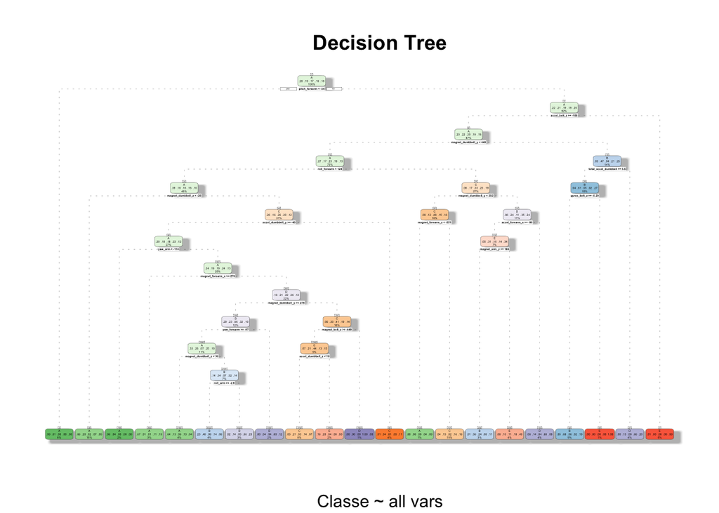

```r
mod_dt <- rpart(classe ~ ., data = train, method = "class")

fancyRpartPlot(mod_dt, main = "Decision Tree", sub = "Classe ~ all vars")
```

Prediction on validation set

```r
predict_dt <- predict(mod_dt, newdata=validation, type="class")
conf_mat_dt <- confusionMatrix(predict_dt, validation$classe)
conf_mat_dt
```

```
## Confusion Matrix and Statistics
##
##           Reference
## Prediction    A    B    C    D    E
##          A 1472  240   21  135   92
##          B   97  522   86   71  149
##          C   45  236  865  201  188
##          D   21   87   27  516  110
##          E   39   54   27   41  543
##
## Overall Statistics
##
##                Accuracy : 0.6658
##                  95% CI : (0.6535, 0.6778)
##     No Information Rate : 0.2845
##     P-Value [Acc > NIR] : < 2.2e-16
##
##                   Kappa : 0.5749
##  Mcnemar's Test P-Value : < 2.2e-16
##
## Statistics by Class:
##
##                      Class: A Class: B Class: C Class: D Class: E
## Sensitivity            0.8793   0.4583   0.8431  0.53527  0.50185
## Specificity            0.8841   0.9151   0.8621  0.95021  0.96648
## Pos Pred Value         0.7510   0.5643   0.5635  0.67806  0.77131
## Neg Pred Value         0.9485   0.8756   0.9630  0.91257  0.89597
## Prevalence             0.2845   0.1935   0.1743  0.16381  0.18386
## Detection Rate         0.2501   0.0887   0.1470  0.08768  0.09227
## Detection Prevalence   0.3331   0.1572   0.2608  0.12931  0.11963
## Balanced Accuracy      0.8817   0.6867   0.8526  0.74274  0.73416
```

### 4. Outcome

We can see that the Random Forest outperforms both the gbm and the decision tree in terms of accuracy (0.9893 vs. 0.9602, and 0.6658 respectively) - the latter performs worst.

### 5. Applying mod_rf to our testing set

The Random Forest model will be applied to predict the 20 quiz results (testing dataset):

```r
predict_test <- predict(mod_rf, newdata=test_pml)
predict_test
```

```
##  [1] B A B A A E D B A A B C B A E E A B B B
## Levels: A B C D E
```